# Preliminary Analysis

Jon Geiger, Noel Goodwin, Abigail Joppa

2022-04-01

# Importing Packages

```r
library(tidyverse)
```

```r
library(readxl)
library(corrplot)
```

# Importing and Cleaning Data

```r
district_data <- read_excel("NHGIS_District_data.xlsx")
```

Fortunately, there isn’t much initial restructuring required of this data.

```r
names(district_data)
```

```
##  [1] "School ID"
##  [2] "State"
##  [3] "Geographic School District"
##  [4] "Children 5-17 (SAIPE Estimate)"
##  [5] "% Poverty (SAIPE Estimate)"
##  [6] "% Single Parent Estimate"
##  [7] "Single Parent Margin of Error"
##  [8] "% HHs With Vulnerable Job Estimate"
##  [9] "Vulnerable Job Margin of Error"
## [10] "% Crowded Conditions Estimate"
## [11] "HH With Crowded Conditions Margin of Error"
## [12] "% No Computer or Internet Estimate"
## [13] "No Computer or Internet Margin of Error"
## [14] "% Children with Disability"
## [15] "Children with Disability Margin of Error"
## [16] "% Linguistically Isolated Children"
## [17] "Linguistically Isolated Children Margin of Error"
```

Let’s work on renaming our variables to more `R`-friendly names.

```r
names_list <- c(
    "school_ID",
    "state",
    "dist",  # Geographic School District
    "children", # Children 5-17 (SAIPE Estimate)
    "pct_pov", # % Poverty (SAIPE Estimate)
    "pct_SP", # % Single Parent Estimate
    "SP_MOE", # Single Parent Margin of Error
    "pct_HHVJ", # % HHs With Vulnerable Job Estimate
    "HHVJ_MOE", # Vulnerable Job Margin of Error
    "pct_CC", # % Crowded Conditions Estimate
    "CC_MOE", # HH With Crowded Conditions Margin of Error
    "pct_NCI", # % No Computer or Internet Estimate
    "nci_MOE", # No Computer or Internet Margin of Error
    "pct_CD", # % Children with Disability
    "CD_MOE", # Children with Disability Margin of Error
    "pct_CLI", # % Linguistically Isolated Children
    "CLI_MOE" # Linguistically Isolated Children Margin of Error
)
names(district_data) <- names_list
district_pcts <- district_data %>%
    select(-ends_with("MOE"))
```

We make a new dataset, `district_pcts`, which contains all the values without any of the margins of error.

We can now do some preliminary analysis on this data. Let’s first see if there’s any NA/missing data:

```r
district_data %>%
    is.na() %>%
    colSums()
```

```
## school_ID     state      dist  children   pct_pov    pct_SP    SP_MOE  pct_HHVJ
##         0         0         0         0         0         0         0         0
##  HHVJ_MOE    pct_CC    CC_MOE   pct_NCI   nci_MOE    pct_CD    CD_MOE   pct_CLI
##         0         0         0         0         0         0         0         0
##   CLI_MOE
##         0
```

Fortunately, there don’t appear to be any NA values in any of the percentage columns.

Let’s check out some variable correlations:

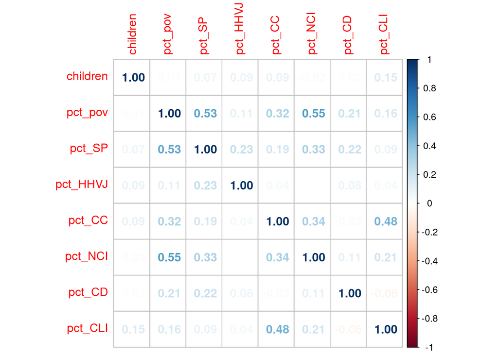

```r
district_pcts[,4:ncol(district_pcts)] %>%
    cor() %>%
    corrplot(method = "number")
```

Based on the correlations, it might make sense to plot some variables against each other to see some initial trends. We will choose a cutoff correlation value of 0.3 to distinguish variables which may be of interest. This is completely arbitrary, but limits the amount of plots we need to make such that the analysis is not entirely cumbersome.

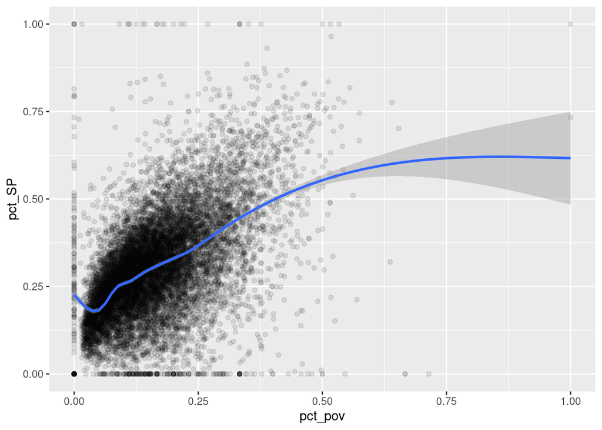

```r
ggplot(district_pcts,
       aes(x = pct_pov,
           y = pct_SP
       )) +
    geom_point(alpha = 0.1) +
    geom_smooth()
```

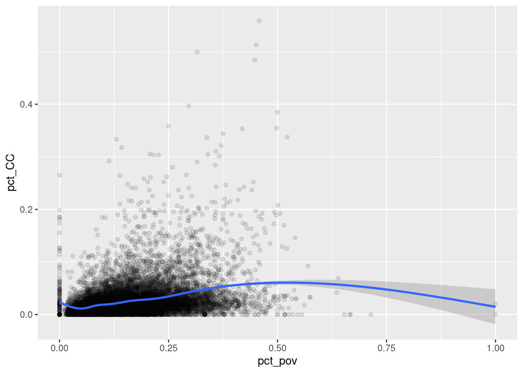

```r
ggplot(district_pcts,
       aes(x = pct_pov,
           y = pct_CC
       )) +
    geom_point(alpha = 0.1) +
    geom_smooth()
```

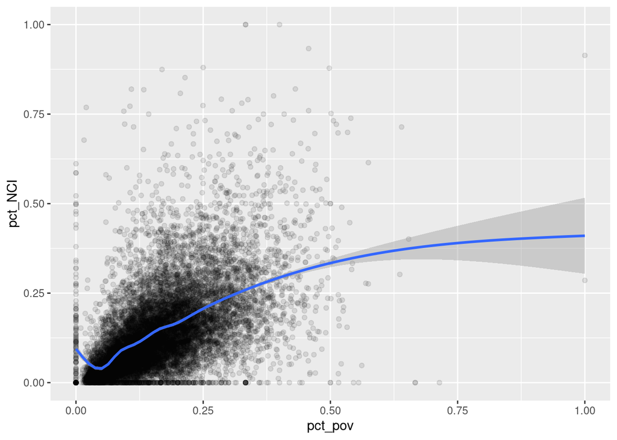

```r
ggplot(district_pcts,
       aes(x = pct_pov,
           y = pct_NCI
       )) +
    geom_point(alpha = 0.1) +
    geom_smooth()
```

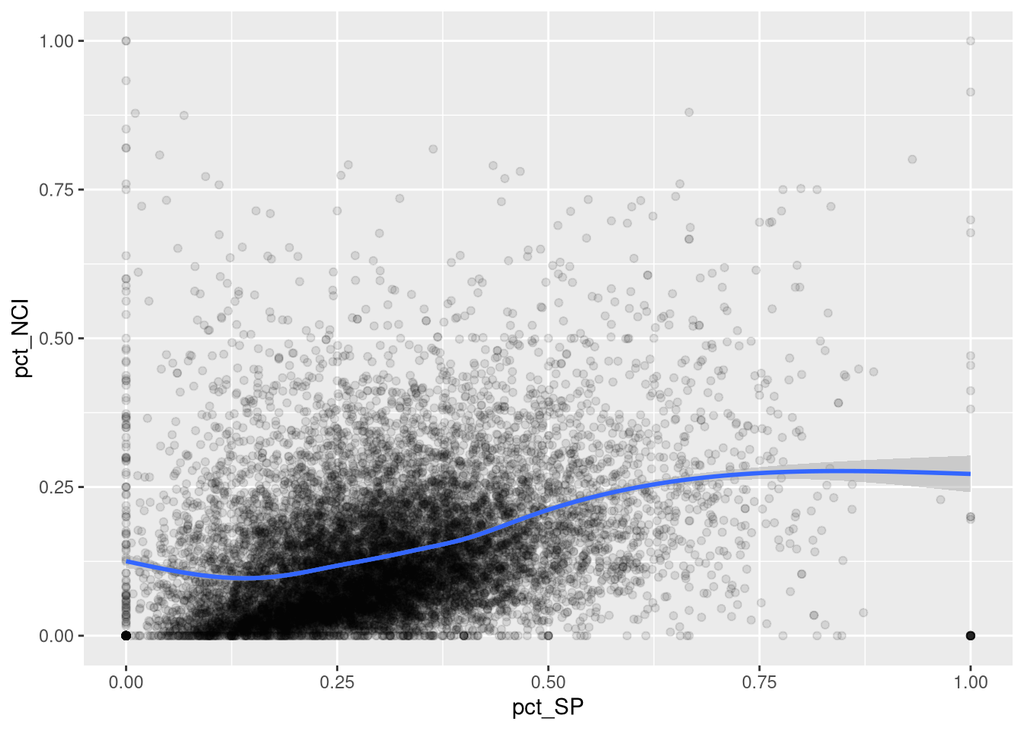

```r
ggplot(district_pcts,
       aes(x = pct_SP,
           y = pct_NCI
       )) +
    geom_point(alpha = 0.1) +
    geom_smooth()
```

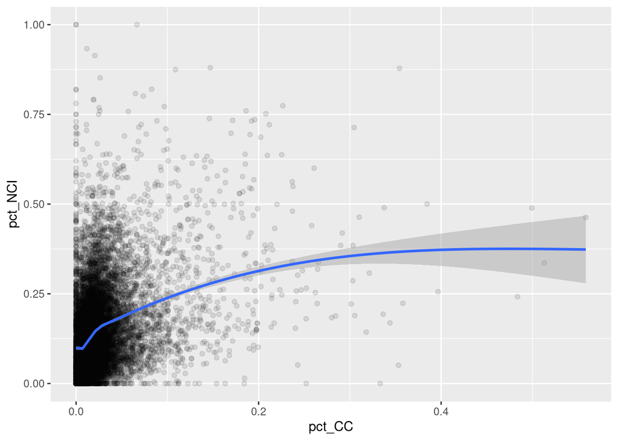

```r
ggplot(district_pcts,
       aes(x = pct_CC,
           y = pct_NCI
       )) +
    geom_point(alpha = 0.1) +
    geom_smooth()
```

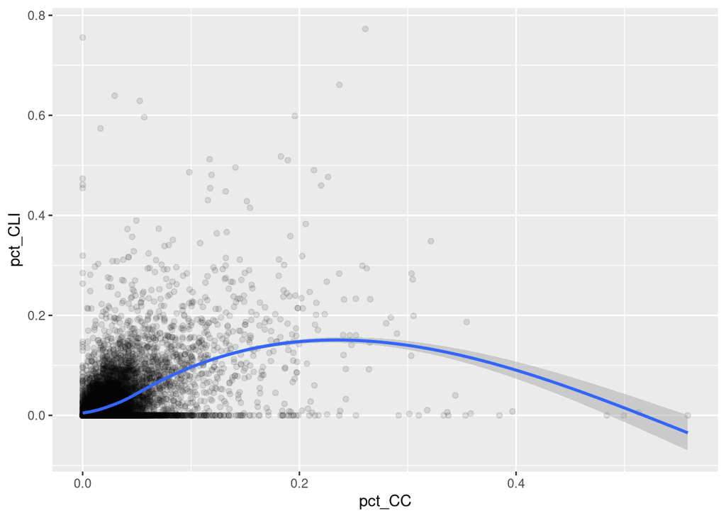

```r
ggplot(district_pcts,
       aes(x = pct_CC,
           y = pct_CLI
       )) +
    geom_point(alpha = 0.1) +
    geom_smooth()
```

Immediately from all of these plots, we can notice that the vast majority of values for any given predictor are below 50%. Some trends emerge from the smoother, but for the purposes of trends or reasonable analysis, it may be useful to eliminate some influential points, which occur at the 100% marks.

As an example, we can look at the variable `pct_pov`, which is used in the second plot created. There are two data points at the 100% mark, so let’s look at these values:

```r
district_data %>%
    filter(pct_pov == 1) %>%
    arrange(pct_pov) %>%
    select(state, dist, children, pct_pov)
```

```
## # A tibble: 2 × 4
##   state      dist                       children pct_pov
##   <chr>      <chr>                         <dbl>   <dbl>
## 1 Maine      Seboeis Plantation               17       1
## 2 New Mexico Wagon Mound Public Schools       59       1
```

We can immediately notice that these school districts have very few children from the ages of 5 to 17 in them. Let’s look at a summary of the distribution of children across school districts:

```r
summary(district_data$children)
```

```
##    Min. 1st Qu.  Median    Mean 3rd Qu.    Max.
##       0     445    1264    4353    3458 1213005
```

The mean of this distribution is well above the third quartile, implying that this data is heavily right-skewed. This makes sense, given the fact that there are so many small school districts and likely a few very large ones.

Because of the right-skewed nature of this data, let’s look at a log-transformed boxplot

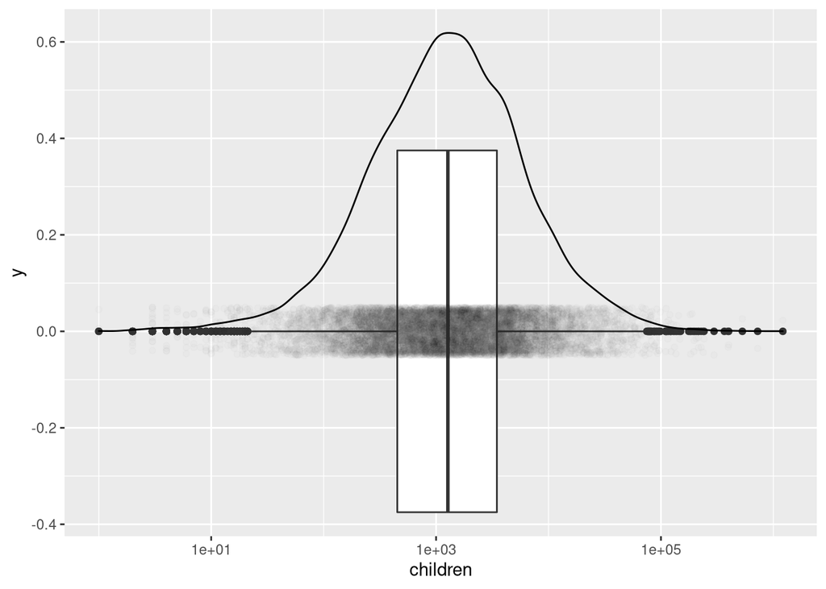

```r
ggplot(district_data, aes(x = children)) +
    geom_boxplot() +
    geom_jitter(aes(y = 0), alpha = 0.01, height = 0.05) +
    scale_x_log10() +
    geom_density()
```

Additionally, let’s see which school district has over a million estimated children aged 5 to 17.

```r
district_data %>%
    select(state, dist, children) %>%
    arrange(desc(children)) %>%
    head(5)
```

```
## # A tibble: 5 × 3
##   state       dist                                  children
##   <chr>       <chr>                                    <dbl>
## 1 New York    New York City Department Of Education  1213005
## 2 California  Los Angeles Unified School District     724446
## 3 Puerto Rico Puerto Rico                             529844
## 4 Illinois    Chicago Public School District 299      399883
## 5 Florida     Dade County School District             396516
```

Makes sense. Is this actually a school district, or is it a conglomerate of school districts? We’ll assume that the data is good, and that the New York City Department of Education is, in fact, classified as a school district.

Generally, it appears that there are many school districts with zero students, which introduces issues when estimating percentages for different statistics. We will remove these school districts, as they offer no important information.

```r
district_filtered <- district_data %>%
    filter(children > 0)
nrow(district_data) - nrow(district_filtered)
```

```
## [1] 46
```

We can see that we removed 46 observations, or that there were 46 schools which reported no children in that school district.

```r
#'
#' TODO: Start to visualize margins of error for different measures
#' TODO: Plot variables against each other with non-negligible correlations
#' TODO: Decide on an analysis/visualization color scheme/theme (separate file)
#'
#'
```